# Análisis descriptivo de datos - Socialización de la meritocracia

Castillo, J.C., Iturra, J., Meneses, F. & Venegas, M.

2021-03-05

# Introducción

El presente documento tiene por finalidad el análisis incial de datos para el artículo “La socialización de la meritocracia: el rol de la familia y la escuela” a cargo de Juan Carlos Castillo. El artículo se desarrolla en el marco del proyecto FONDECYT Regular N°1181239: “Socialización política y educación para la ciudadanía: el rol de la familia y de la escuela”.

El documento se estructurará en tres apartados. El primero corresponde a la carga de datos y las librerías. El segundo a los análisis descriptivos univariados. El tercero a la sección de análisis descriptivos bivariados.

# Resumen ejecutivo:

## Registro de cambios desde reunión 21-1-21

- Uso de nueva base a partir de cambios en el procesamiento.
- Cambio en el nombre de variable *get ahead* por *esfuerzo*
- na.omit eliminado en gráficos Likert
- na.omit sustituido por listwise deletion en correlaciones. NOTA: Se agrega el argumento *complete.obs*
- Incorporación propuesta Francisco

## Parte 1: Cargar ibrerías y datos

```r
# Cargar librerías
pacman::p_load(dplyr, #Manipulacion de datos
              stargazer, #Tablas
              sjmisc, # Tablas
              summarytools, # Tablas
              kableExtra, #Tablas
              sjPlot, #Tablas y gráficos
              corrplot, # Correlaciones
              sessioninfo, #  Información de la sesión de trabajo
              ggplot2, # Graficos
              sjlabelled) #Etiquetas

# Cargar datos
load(file = "../input/data/ap_est.RData") # Base conjunta
```

## Parte 2: Análisis descriptivos univariados

### Descriptivos univariados generales

A continuación se presentan los descriptivos de la base de datos completa:

```r
sjPlot::view_df(ap_est, show.type = T, show.prc = T, show.na = T)
```

Data frame: ap_est

| ID | Name | Type | Label | missings | Values | Value Labels | % |
| --- | --- | --- | --- | --- | --- | --- | --- |
| 1 | rbd_est | numeric | RBD RBD | 0 (0.00%) | 217 218 219 253 254 255 256 257 279 280 284 285 286 287 304 <…> | LICEO LUIS CRUZ MARTINEZ LICEO FRANCISCO DE AGUIRRE LICEO POLITECNICO CESAREO AGUIRRE G. COLEGIO ADVENTISTA DE CALAMA FUNDACION EDUC.COLEGIO NUESTRA SRA.DE AYQUINA COLEGIO EJERCITO DE SALVACION INSTIT… | 0.00 1.35 0.00 0.00 0.00 0.00 0.00 0.00 2.39 1.35 0.00 1.04 1.47 0.00 0.00 |
| 2 | region_est | numeric | Region | 0 (0.00%) | 2 7 13 | Región de Antofagasta Región del Maule Región Metropolitana | 24.89 21.65 53.46 |
| 3 | folio | numeric | FOLIO Folio | 0 (0.00%) | *range: 1-20390* |  |  |
| 4 | dependencia_est | numeric | Dependencia | 0 (0.00%) | 1 2 3 | Municipal Part. Subvencionado Part.Privado | 37.00 47.71 15.29 |
| 5 | pos_pol_est | numeric | Posicion politica estudiantes | 25 (1.53%) | 1 2 3 4 5 6 7 99 | Derecha Centro derecha Centro Centro Izquierda Izquierda Independiente Ninguna Ns/Nr | 10.62 4.97 3.73 4.97 5.09 4.04 21.86 44.72 |
| 6 | genero_est | numeric | Genero estudiantes | 25 (1.53%) | 1 2 3 | Hombre Mujer Otro | 51.80 46.15 2.05 |
| 7 | educ_padre | numeric | Educacion de la madre | 224 (13.70%) | 1 2 3 4 5 | No completó 8vo Básico 8vo básico Educación media Educación Técnica superior (Instituto profesional o Centro de Formación Técn Una carrera en la Universidad o estudios de posgrado (Magíster o… | 6.17 8.72 38.34 23.95 22.82 |
| 8 | educ_madre | numeric | Educacion de la madre | 181 (11.07%) | 1 2 3 4 5 | No completó 8vo Básico 8vo básico Educación media Educación Técnica superior (Instituto profesional o Centro de Formación Técn Una carrera en la Universidad o estudios de posgrado (Magíster o… | 6.12 8.12 38.93 25.24 21.60 |
| 9 | libros_hogar_est | numeric | Libros en el hogar estudiantes | 147 (8.99%) | 1 2 3 4 5 6 | Entre 0 y 10 libros Entre 11 y 25 libros Entre 26 y 100 libros Entre 101 y 200 libros Entre 201 y 500 libros Más de 500 libros | 22.18 23.39 29.17 13.51 7.59 4.17 |
| 10 | perc_trabajo_duro_est | numeric | Percepcion meritocracia: Importancia trabajo duro estudiantes | 47 (2.87%) | 1 2 3 4 | Nada importante Algo importante Importante Muy importante | 4.35 12.22 26.01 57.43 |
| 11 | perc_familia_rica_est | numeric | P24A Actualmente en Chile, para surgir en la vida ¿Cuán importante esPROVENIR DE | 0 (0.00%) | 1 2 3 4 5 9 | Nada importante Algo importante Importante Muy importante Mbackground-color:#eeeeeea mas de 1 alternativa Nr | 19.94 31.07 25.32 20.92 0.00 2.75 |
| 12 | perc_esfuerzo_est | numeric | Percepcion meritocracia: Esfuerzo para salir adelante estudiantes | 67 (4.10%) | 1 2 3 4 | Muy en desacuerdo En desacuerdo De acuerdo Muy de acuerdo | 3.76 14.48 44.64 37.12 |
| 13 | prom_obt | numeric | Promedio obtenido | 136 (8.32%) | 99 | Nr | 0.07 |
| 14 | prom_mer | numeric | Promedio merecido | 165 (10.09%) | 99 | Nr | 0.07 |
| 15 | sj_direct | numeric | Sentido de justicia directo | 94 (5.75%) | 1 2 3 | Menos de las que merezco Las que merezco Más de las que merezco | 22.65 63.47 13.89 |
| 16 | recompensa | numeric | Recompensa en la escuela estudiantes | 67 (4.10%) | 1 2 3 4 | Muy en desacuerdo En desacuerdo De acuerdo Muy de acuerdo | 10.14 23.79 49.87 16.20 |
| 17 | perc_falta_talento_est | numeric | P26A ¿Con qué frecuencia las siguientes razones podrían ser la causa de la pobre | 0 (0.00%) | 1 2 3 4 5 9 | Nunca Casi nunca A veces Siempre Mbackground-color:#eeeeeea mas de 1 alternativa Nr | 26.61 32.54 30.89 5.14 0.00 4.83 |
| 18 | perc_falta_esfuerzo_est | numeric | P26C ¿Con qué frecuencia las siguientes razones podrían ser la causa de la pobre | 0 (0.00%) | 1 2 3 4 5 9 | Nunca Casi nunca A veces Siempre Mbackground-color:#eeeeeea mas de 1 alternativa Nr | 19.51 22.75 40.06 12.29 0.31 5.08 |
| 19 | perc_faltasist_econ_est | numeric | P26D ¿Con qué frecuencia las siguientes razones podrían ser la causa de la pobre | 0 (0.00%) | 1 2 3 4 5 9 | Nunca Casi nunca A veces Siempre Mbackground-color:#eeeeeea mas de 1 alternativa Nr | 4.65 12.05 45.99 32.29 0.12 4.89 |
| 20 | perc_faltasist_educ_est | numeric | P26E ¿Con qué frecuencia las siguientes razones podrían ser la causa de la pobre | 0 (0.00%) | 1 2 3 4 5 9 | Nunca Casi nunca A veces Siempre Mbackground-color:#eeeeeea mas de 1 alternativa Nr | 5.44 14.37 45.38 29.85 0.06 4.89 |
| 21 | prom_percmer_est | numeric |  | 80 (4.89%) | *range: 1.0-4.0* |  |  |
| 22 | sj_indirect_ln | numeric | Sentido de justicia indirecto | 171 (10.46%) | *range: -0.9-1.1* |  |  |
| 23 | sj_indirect_noln | numeric | Sentido de justicia indirecto SIN LN | 171 (10.46%) | *range: -0.9-1.1* |  |  |
| 24 | rbd_ap | numeric | RBD RBD | 919 (56.21%) | 217 218 219 253 254 255 256 257 279 280 284 285 286 287 304 <…> | LICEO LUIS CRUZ MARTINEZ LICEO FRANCISCO DE AGUIRRE LICEO POLITECNICO CESAREO AGUIRRE G. COLEGIO ADVENTISTA DE CALAMA FUNDACION EDUC.COLEGIO NUESTRA SRA.DE AYQUINA COLEGIO EJERCITO DE SALVACION INSTIT… | 0.00 1.82 0.00 0.00 0.00 0.00 0.00 0.00 0.00 0.84 0.00 1.26 0.84 0.00 0.00 |
| 25 | region_ap | numeric | Region | 919 (56.21%) | 2 7 13 | Región de Antofagasta Región del Maule Región Metropolitana | 16.48 29.61 53.91 |
| 26 | dependencia_ap | numeric | Depedencia | 919 (56.21%) | 1 2 3 | Municipal Part. Subvencionado Part. Privado | 31.28 54.33 14.39 |
| 27 | pos_pol_ap | numeric | Posicion politica apoderados | 919 (56.21%) | 1 2 3 4 5 6 7 10 | Derecha Centro derecha Centro Centro Izquierda Izquierda Independiente Ninguna Ns/Nr | 7.54 6.28 2.93 5.73 6.42 6.70 48.18 16.20 |
| 28 | genero_ap | numeric | Genero apoderados | 919 (56.21%) | 1 2 3 | Hombre Mujer Otro | 18.58 81.28 0.14 |
| 29 | nacimiento | numeric | Nacimiento apoderado | 1010 (61.77%) | 9999 | Nr | 0.16 |
| 30 | personas_hogar | numeric | Cantidad de personas en el hogar | 966 (59.08%) | 999 | Nr | 0.15 |
| 31 | educ | numeric | Educacion del apoderado | 952 (58.23%) | 1 2 3 4 | 8vo básico o menos Educación Media Educación Técnica Superior (Instituto Profesional o Centro de Formación Técn Una carrera en la Universidad o estudios de Posgrado (Magíster o Doctorado) | 11.27 44.22 25.92 18.59 |
| 32 | ingresos_tramos | numeric | Ingresos del hogar en tramos | 919 (56.21%) | 1 2 3 4 5 6 7 8 9 10 11 | Menos de $101.000 mensuales líquidos De $101.001 a $134.000 mensuales líquidos De $134.001 a $179.000 mensuales líquidos De $179.001 a $224.000 mensuales líquidos De $224.001 a $291.000 mensuales … | 1.82 1.96 1.68 3.91 5.45 12.57 15.08 19.27 10.75 2.37 5.59 |
| 33 | libros_hogar_ap | numeric | Libros en el hogar apoderados | 950 (58.10%) | 1 2 3 4 5 6 | Entre 0 y 10 libros Entre 11 y 25 libros Entre 26 y 100 libros Entre 101 y 200 libros Entre 201 y 500 libros Más de 500 libros | 19.42 28.91 35.04 10.66 4.67 1.31 |
| 34 | perc_trabajo_duro_ap | numeric | Percepcion meritocracia: Importancia trabajo duro apoderados | 948 (57.98%) | 1 2 3 4 | Nada importante Algo importante Importante Muy importante | 6.40 12.37 31.44 49.78 |
| 35 | perc_familia_rica_ap | numeric | P9A Actualmente en Chile, para surgir en la vida ¿Cuán importante esPROVENIR DE | 919 (56.21%) | 1 2 3 4 9 | Nada importante Algo importante Importante Muy importante Nr | 24.72 23.04 24.30 23.18 4.75 |
| 36 | perc_esfuerzo_ap | numeric | Percepcion meritocracia: Esfuerzo para salir adelante apoderados | 953 (58.29%) | 1 2 3 4 | Muy en desacuerdo En desacuerdo De acuerdo Muy de acuerdo | 3.52 14.52 46.33 35.63 |
| 37 | recompensa_hijos | numeric | Recompensa en la escuela apoderados | 969 (59.27%) | 1 2 3 4 | Muy en desacuerdo En desacuerdo De acuerdo Muy de acuerdo | 5.11 19.97 53.60 21.32 |
| 38 | perc_falta_talento_ap | numeric | P11A ¿Con qué frecuencia las siguientes razones podrían ser la causa de la pobre | 919 (56.21%) | 1 2 3 4 9 | Nunca Casi nunca Casi siempre Siempre Nr | 28.63 35.20 23.88 6.84 5.45 |
| 39 | perc_falta_esfuerzo_ap | numeric | P11C ¿Con qué frecuencia las siguientes razones podrían ser la causa de la pobre | 919 (56.21%) | 1 2 3 4 9 | Nunca Casi nunca Casi siempre Siempre Nr | 21.79 24.72 33.80 12.99 6.70 |
| 40 | perc_faltasist_econ_ap | numeric | P11D ¿Con qué frecuencia las siguientes razones podrían ser la causa de la pobre | 919 (56.21%) | 1 2 3 4 9 | Nunca Casi nunca Casi siempre Siempre Nr | 3.63 8.94 39.94 44.41 3.07 |
| 41 | perc_faltasist_educ_ap | numeric | P11E ¿Con qué frecuencia las siguientes razones podrían ser la causa de la pobre | 919 (56.21%) | 1 2 3 4 9 | Nunca Casi nunca Casi siempre Siempre Nr | 4.33 8.10 36.73 47.35 3.49 |
| 42 | prom_percmer_ap | numeric | Promedio percepcion meritocratica apoderados | 948 (57.98%) | *range: 1.0-6.5* |  |  |
| 43 | ingresos | numeric | Ingresos del hogar | 1059 (64.77%) | *range: 50500-3500000* |  |  |
| 44 | ingresos_pc | numeric | Ingreso per capita | 1059 (64.77%) | *range: 201-1750000* |  |  |
| 45 | edad | numeric | Edad apoderado | 1010 (61.77%) | *range: 27-86* |  |  |
| 46 | ingresos_esc | numeric | Ingresos por escuela | 925 (56.57%) | *range: 187500.0-3000000.0* |  |  |
| 47 | ingresos_pc_esc | numeric | Ingreso per capita por escuela | 925 (56.57%) | *range: 43368.0-947400.0* |  |  |
| 48 | univ | numeric | Educacion terciaria apoderados | 952 (58.23%) | 0 1 | No universitario Universitario | 81.41 18.59 |
| 49 | univ_esc | numeric | Porcentaje ed. terciaria por escuela | 919 (56.21%) | *range: 0.0-0.9* |  |  |
| 50 | heterogen_esc | numeric | Heterogeneidad de la escuela | 925 (56.57%) | *range: 38682.5-2189909.7* |  |  |

### Descriptivos univariados variables de hipotesis

Se realizan dos gráficos para variables likert. El primero corresponde a la comparación de percepción del trabajo duro en estudiates y apoderados. El segundo es la misma comparación pero para la percepción de esfuerzo.

```r
# Plot Likert: perc. trabajo duro apoderados y estudiantes

baselik<- ap_est %>% select(perc_trabajo_duro_est,perc_trabajo_duro_ap)

# short var labels
items <- c("Percepcion trabajo duro estudiantes", "Percepcion trabajo duro apoderados")

# cambiar orden para la leyenda
labels= c("Nada Importante", "Poco Importante", "Importante", "Muy Importante")  ### E

#save
png("../output/images/Plot-lik-trabajoduro.png", width = 750, height = 300)
sjPlot::plot_likert(baselik,
                         axis.labels   = items,
                         legend.labels = labels,
                         legend.pos = "bottom",
                         #cat.neutral   = , # identifica a indiferentes
                         geom.colors   = c("#9ECAE1", "#6BAED6", "#4292C6",
                                           "#2171B5"), # colorbrewer2.org
                         sort.frq      = "neg.asc", # sort descending)
                         title         = "Percepción de meritocracia Apoderados e hijos",
                         intercept.line.color = "white", # vertical middle
                         expand.grid   = F, # no inner margins in plot
                         show.n        = FALSE, # hide N's in axis labels
                         grid.range    = 1.8,
                         geom.size = 0.6, values = "sum.outside")
dev.off()
```

```r
# Plot Likert: perc. esfuerzo apoderados y estudiantes

baselik<- ap_est %>% select(perc_esfuerzo_est,perc_esfuerzo_ap)

# short var labels
items <- c("Percepcion esfuerzo estudiantes", "Percepcion esfuerzo apoderados")

# cambiar orden para la leyenda
labels= c("Muy en desacuerdo", "En desacuerdo", "De acuerdo", "Muy de acuerdo")  ### E

# save
png("../output/images/Plot-lik-esfuerzo.png", width = 750, height = 300)
sjPlot::plot_likert(baselik,
                         axis.labels   = items,
                         legend.labels = labels,
                         legend.pos = "bottom",
                         #cat.neutral   = , # identifica a indiferentes
                         geom.colors   = c("#9ECAE1", "#6BAED6", "#4292C6",
                                           "#2171B5"), # colorbrewer2.org
                         sort.frq      = "neg.asc", # sort descending)
                         title         = "Percepción de meritocracia Apoderados e hijos",
                         intercept.line.color = "white", # vertical middle
                         expand.grid   = F, # no inner margins in plot
                         show.n        = FALSE, # hide N's in axis labels
                         grid.range    = 1.8,
                         geom.size = 0.6, values = "sum.outside")
dev.off()
```

### Descriptivos sentidos de justicia

```r
select(ap_est, sj_indirect_ln, sj_indirect_noln, sj_direct) %>% summarytools::descr()
```

Descriptive Statistics

|  | sj_direct | sj_indirect_ln | sj_indirect_noln |
| --- | --- | --- | --- |
| Mean | 1.91 | -0.04 | -0.04 |
| Std.Dev | 0.60 | 0.11 | 0.11 |
| Min | 1.00 | -0.88 | -0.88 |
| Q1 | 2.00 | -0.07 | -0.07 |
| Median | 2.00 | -0.03 | -0.03 |
| Q3 | 2.00 | 0.00 | 0.00 |
| Max | 3.00 | 1.06 | 1.06 |
| MAD | 0.00 | 0.05 | 0.05 |
| IQR | 0.00 | 0.07 | 0.07 |
| CV | 0.31 | -2.87 | -2.87 |
| Skewness | 0.03 | 1.82 | 1.82 |
| SE.Skewness | 0.06 | 0.06 | 0.06 |
| Kurtosis | -0.26 | 30.98 | 30.98 |
| N.Valid | 1541.00 | 1464.00 | 1464.00 |
| Pct.Valid | 94.25 | 89.54 | 89.54 |

## Parte 3: Análisis descriptivo bivariado

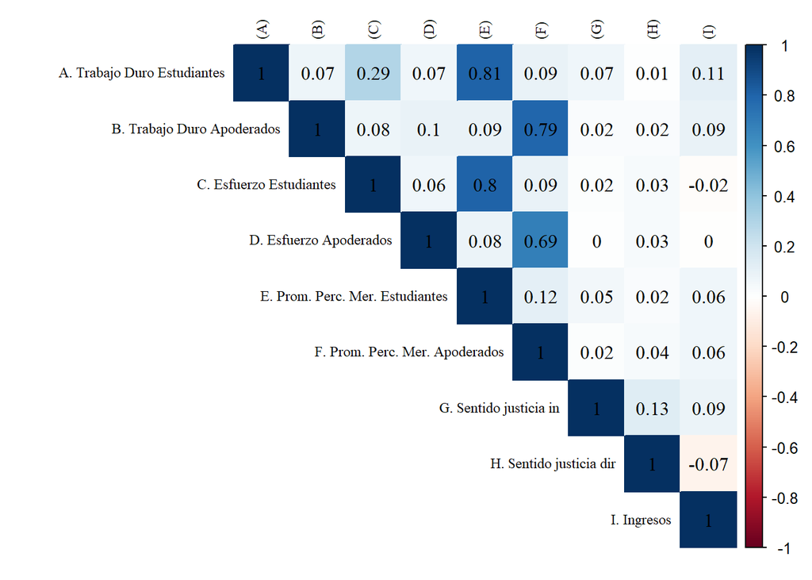

```r
# Matriz de correlación entre variales principales

basecor<- ap_est %>% select(perc_trabajo_duro_est,perc_trabajo_duro_ap,perc_esfuerzo_est,perc_esfuerzo_ap,prom_percmer_est,prom_percmer_ap,sj_indirect_ln,sj_direct,ingresos_pc_esc)
cormat=cor(basecor, use = "complete.obs")
#save
#png("../output/images/correlacionl1.png",width=600,height=600)
windowsFonts(A = windowsFont("Times New Roman"))
rownames(cormat) <-c(
    "A. Trabajo Duro Estudiantes",
    "B. Trabajo Duro Apoderados",
    "C. Esfuerzo Estudiantes",
    "D. Esfuerzo Apoderados",
    "E. Prom. Perc. Mer. Estudiantes",
    "F. Prom. Perc. Mer. Apoderados",
    "G. Sentido justicia in",
    "H. Sentido justicia dir",
    "I. Ingresos")
colnames(cormat) <-c("(A)", "(B)","(C)","(D)","(E)","(F)", "(G)", "(H)", "(I)")
corrplot(
cormat,
  method = "color",
  type = "upper",
  tl.col = "black",
  addCoef.col = "black",
  diag = TRUE,
  family = "A",
  number.font = 6,
  tl.cex =0.75,
  number.cex = 1)
```

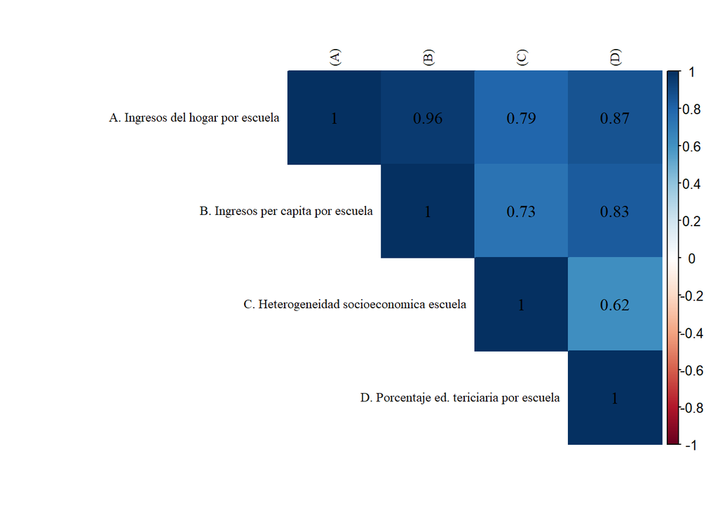

```r
# Matriz de correlación entre variables nivel 2

basecor<- ap_est %>% select(ingresos_esc, ingresos_pc_esc, heterogen_esc, univ_esc)
cormat=cor(basecor, use = "complete.obs")
#save
#png("../output/images/correlacionl2.png",width=600,height=600)
windowsFonts(A = windowsFont("Times New Roman"))
rownames(cormat) <-c(
    "A. Ingresos del hogar por escuela",
    "B. Ingresos per capita por escuela",
    "C. Heterogeneidad socioeconomica escuela",
    "D. Porcentaje ed. tericiaria por escuela")
colnames(cormat) <-c("(A)", "(B)","(C)","(D)")
corrplot(
cormat,
  method = "color",
  type = "upper",
  tl.col = "black",
  addCoef.col = "black",
  diag = TRUE,
  family = "A",
  number.font = 6,
  tl.cex =0.75,
  number.cex = 1)
```

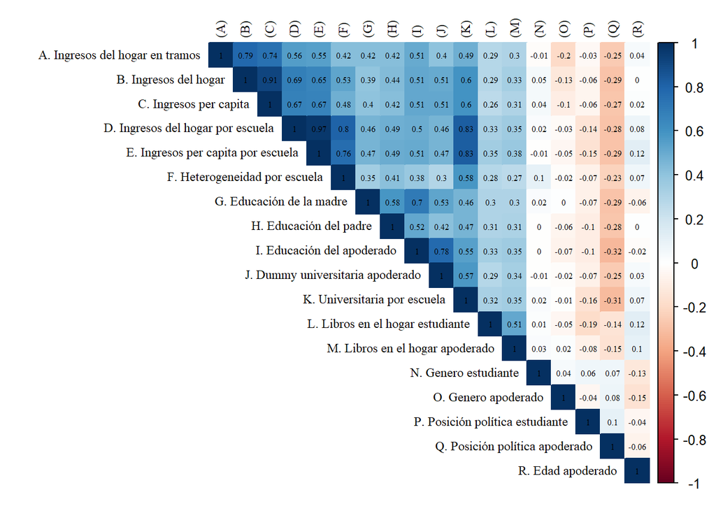

```r
# Matriz de correlación entre ingresos + variables control
basecor<- ap_est %>% select(ingresos_tramos, ingresos, ingresos_pc, ingresos_esc, ingresos_pc_esc, heterogen_esc, educ_madre, educ_padre, educ, univ, univ_esc, libros_hogar_est, libros_hogar_ap, genero_est, genero_ap, pos_pol_est, pos_pol_ap, edad )
cormat=cor(basecor, use = "complete.obs")
#save
#png("../output/images/correlacionl2.png",width=600,height=600)
windowsFonts(A = windowsFont("Times New Roman"))
rownames(cormat) <-c(
    "A. Ingresos del hogar en tramos",
    "B. Ingresos del hogar",
    "C. Ingresos per capita",
    "D. Ingresos del hogar por escuela",
    "E. Ingresos per capita por escuela",
    "F. Heterogeneidad por escuela",
    "G. Educación de la madre",
    "H. Educación del padre",
    "I. Educación del apoderado",
    "J. Dummy universitaria apoderado",
    "K. Universitaria por escuela",
    "L. Libros en el hogar estudiante",
    "M. Libros en el hogar apoderado",
    "N. Genero estudiante",
    "O. Genero apoderado",
    "P. Posición política estudiante",
    "Q. Posición política apoderado",
    "R. Edad apoderado")
colnames(cormat) <-c("(A)","(B)","(C)","(D)", "(E)", "(F)",  "(G)",  "(H)",  "(I)",  "(J)",  "(K)",  "(L)",  "(M)",  "(N)",  "(O)",  "(P)",  "(Q)",  "(R)")
corrplot(
cormat,
  method = "color",
  type = "upper",
  tl.col = "black",
  addCoef.col = "black",
  diag = TRUE,
  family = "A",
  number.font = 6,
  tl.cex =0.75,
  number.cex = 0.5)
```

### Propuesta Francisco

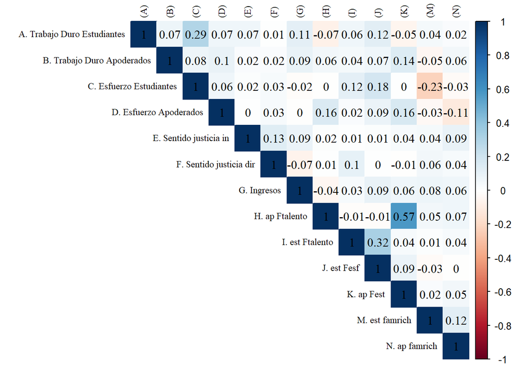

```r
# Matriz de correlación con otras variables de interés

basecor<- ap_est %>% select(perc_trabajo_duro_est,perc_trabajo_duro_ap,perc_esfuerzo_est,perc_esfuerzo_ap,sj_indirect_ln,sj_direct,ingresos_pc_esc, perc_falta_talento_ap, perc_falta_talento_est, perc_falta_esfuerzo_est, perc_falta_esfuerzo_ap, perc_familia_rica_est, perc_familia_rica_ap)

cormat=cor(basecor, use = "complete.obs")
windowsFonts(A = windowsFont("Times New Roman"))
rownames(cormat) <-c(
    "A. Trabajo Duro Estudiantes",
    "B. Trabajo Duro Apoderados",
    "C. Esfuerzo Estudiantes",
    "D. Esfuerzo Apoderados",
    "E. Sentido justicia in",
    "F. Sentido justicia dir",
    "G. Ingresos",
    "H. ap Ftalento",
    "I. est Ftalento",
    "J. est Fesf",
    "K. ap Fest",
    "M. est famrich",
    "N. ap famrich")
colnames(cormat) <-c("(A)", "(B)","(C)","(D)","(E)","(F)", "(G)", "(H)","(I)", "(J)","(K)","(M)","(N)")
corrplot(
cormat,
  method = "color",
  type = "upper",
  tl.col = "black",
  addCoef.col = "black",
  diag = TRUE,
  family = "A",
  number.font = 6,
  tl.cex =0.75,
  number.cex = 1)
```

```r
table(basecor$perc_trabajo_duro_est==basecor$perc_trabajo_duro_ap)
```

```
##
## FALSE  TRUE
##   403   277
```

### Indagación rbd

```r
table(ap_est$rbd_est)
```

```
##
##   218   279   280   285   286   329   366  2737  2943  2974  3003  3006  3248
##    22    39    22    17    24    32    15     7     8    10    11    41    29
##  3296  3300  8535  8681  9075  9082  9276  9697  9855  9867  9940 10452 10456
##    39    45    25    37    22    36    18    27    23    23    33    10    28
## 10457 10507 10544 10573 10968 12823 12868 12884 12977 16415 16443 16453 16550
##    22    38    15    17    28    33    43    36    33    33    15    31    34
## 16588 16652 16656 24403 24971 25171 25182 25220 25458 25654 25671 25770 25929
##    32    16     3    19    20    32    23    22    35    20    10    32    20
## 25988 26046 26219 31047 31074 31080 31340 31343 31373 31378 31379 31421
##    30    24    24    13    36    25    31    32    16    35    40    24
```

```r
base218<- ap_est %>% filter(rbd_est==218)
table(is.na(base218$ingresos_esc))
```

```
##
## FALSE  TRUE
##    13     9
```

```r
table(base218$ingresos_esc)
```

```
##
## 277772.727272727
##               13
```

```r
table(base218$ingresos)
```

```
##
## 117500 201500 257500 324500 403000
##      2      1      2      4      2
```

### Prueba modelo

```r
library(lavaan)
baseafc<- ap_est %>% select(perc_trabajo_duro_est,perc_trabajo_duro_ap,perc_esfuerzo_est,perc_esfuerzo_ap, perc_falta_talento_ap, perc_falta_talento_est, perc_falta_esfuerzo_est, perc_falta_esfuerzo_ap,sj_indirect_noln, ingresos_pc, rbd_est)
baseafc <- set_na(baseafc, na = c(5,9), drop.levels = TRUE, as.tag = FALSE)
baseafc=na.omit(baseafc)



model01 <- 'perc_merit_est=~perc_trabajo_duro_est + perc_esfuerzo_est
            atri_merit_est=~perc_falta_talento_est+perc_falta_esfuerzo_est
            perc_merit_ap=~perc_trabajo_duro_ap + perc_esfuerzo_ap
            atri_merit_ap=~perc_falta_talento_ap+perc_falta_esfuerzo_ap
            '

fit1_o <- cfa(model = model01,data = baseafc,
            ordered = c("perc_trabajo_duro_est","perc_esfuerzo_est","perc_falta_talento_est", "perc_falta_esfuerzo_est","perc_trabajo_duro_ap","perc_esfuerzo_ap","perc_falta_talento_ap","perc_falta_esfuerzo_ap"))

#---------------------------------------------------#
fitMeasures(fit1_o, c("chisq", "df", "pvalue", "cfi", "tli", "rmsea"))
```

```
##  chisq     df pvalue    cfi    tli  rmsea
## 20.141 14.000  0.126  0.985  0.969  0.030
```

```r
summary(fit1_o, fit.measures=T, standardized=T)
```

```
## lavaan 0.6-7 ended normally after 54 iterations
##
##   Estimator                                       DWLS
##   Optimization method                           NLMINB
##   Number of free parameters                         38
##
##   Number of observations                           493
##
## Model Test User Model:
##                                               Standard      Robust
##   Test Statistic                                20.141      24.413
##   Degrees of freedom                                14          14
##   P-value (Chi-square)                           0.126       0.041
##   Scaling correction factor                                  0.860
##   Shift parameter                                            0.992
##        simple second-order correction
##
## Model Test Baseline Model:
##
##   Test statistic                               430.085     381.318
##   Degrees of freedom                                28          28
##   P-value                                        0.000       0.000
##   Scaling correction factor                                  1.138
##
## User Model versus Baseline Model:
##
##   Comparative Fit Index (CFI)                    0.985       0.971
##   Tucker-Lewis Index (TLI)                       0.969       0.941
##
##   Robust Comparative Fit Index (CFI)                            NA
##   Robust Tucker-Lewis Index (TLI)                               NA
##
## Root Mean Square Error of Approximation:
##
##   RMSEA                                          0.030       0.039
##   90 Percent confidence interval - lower         0.000       0.008
##   90 Percent confidence interval - upper         0.057       0.064
##   P-value RMSEA <= 0.05                          0.879       0.740
##
##   Robust RMSEA                                                  NA
```

[output cut: 92 more lines]

```
##     perc_merit_est    0.184    0.074    2.491    0.013    1.000    1.000
##     atri_merit_est    0.160    0.059    2.693    0.007    1.000    1.000
##     perc_merit_ap     0.120    0.054    2.226    0.026    1.000    1.000
##     atri_merit_ap     0.289    0.066    4.345    0.000    1.000    1.000
##
## Scales y*:
##                    Estimate  Std.Err  z-value  P(>|z|)   Std.lv  Std.all
##     prc_trbj_dr_st    1.000                               1.000    1.000
##     perc_esfurz_st    1.000                               1.000    1.000
##     prc_flt_tlnt_s    1.000                               1.000    1.000
##     prc_flt_sfrz_s    1.000                               1.000    1.000
##     perc_trbj_dr_p    1.000                               1.000    1.000
##     perc_esfuerz_p    1.000                               1.000    1.000
##     prc_flt_tlnt_p    1.000                               1.000    1.000
##     prc_flt_sfrz_p    1.000                               1.000    1.000
```

```r
p1a <- predict(fit1_o)
scores_apod = as.data.frame(p1a)
# Merge with factor scores
apod_cfa2_sco = cbind(baseafc, scores_apod)
# Check
stargazer(apod_cfa2_sco, type = "text")
```

```
##
## ======================================================================================
## Statistic                N     Mean      St. Dev.    Min   Pctl(25) Pctl(75)    Max
## --------------------------------------------------------------------------------------
## perc_trabajo_duro_est   493    3.426       0.810      1       3        4         4
## perc_trabajo_duro_ap    493    3.213       0.938      1       3        4         4
## perc_esfuerzo_est       493    3.170       0.821      1       3        4         4
## perc_esfuerzo_ap        493    3.185       0.747      1       3        4         4
## perc_falta_talento_ap   493    2.081       0.909      1       1        3         4
## perc_falta_talento_est  493    2.203       0.895      1       1        3         4
## perc_falta_esfuerzo_est 493    2.491       0.956      1       2        3         4
## perc_falta_esfuerzo_ap  493    2.450       0.992      1       2        3         4
## sj_indirect_noln        493   -0.033       0.081    -0.357  -0.056   0.000     0.936
## ingresos_pc             493 208,417.300 213,451.400  201    80,600  241,333  1,166,666
## rbd_est                 493 15,569.120  10,389.910   218    8,681    25,770   31,421
## perc_merit_est          493   -0.015       0.320    -0.916  -0.177   0.289     0.520
## atri_merit_est          493   -0.002       0.307    -0.671  -0.205   0.185     0.684
## perc_merit_ap           493   -0.002       0.240    -0.659  -0.170   0.154     0.622
## atri_merit_ap           493    0.003       0.425    -0.951  -0.287   0.273     1.028
## --------------------------------------------------------------------------------------
```

```r
# Save  factor scores
```

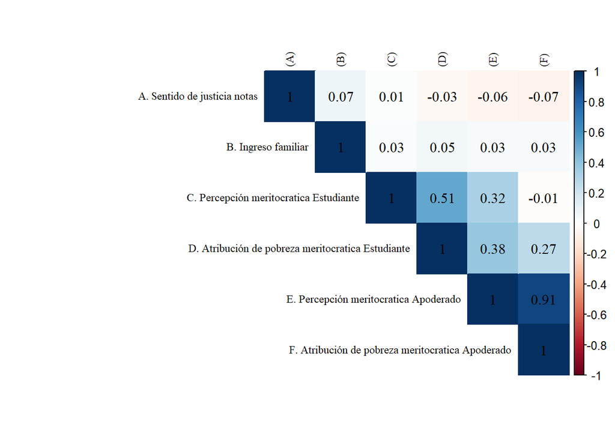

```r
basecor<- apod_cfa2_sco[,9:15]
basecor<- basecor[-c(3)]

#basecor=na.omit(basecor)
cormat=cor(basecor, use = "na.or.complete")

#save
#png("output/results/corplot_totscores.png",width=600,height=600)
windowsFonts(A = windowsFont("Times New Roman"))
rownames(cormat) <-c(
    "A. Sentido de justicia notas",
    "B. Ingreso familiar",
    "C. Percepción meritocratica Estudiante",
    "D. Atribución de pobreza meritocratica Estudiante",
    "E. Percepción meritocratica Apoderado",
    "F. Atribución de pobreza meritocratica Apoderado")
colnames(cormat) <-c("(A)", "(B)","(C)","(D)","(E)","(F)")
corrplot(
cormat,
  method = "color",
  type = "upper",
  tl.col = "black",
  addCoef.col = "black",
  diag = TRUE,
  family = "A",
  number.font = 6,
  tl.cex =0.75,
  number.cex = 1)
```

```r
library(lme4)
library(texreg)
results_0_accum  = lmer(perc_merit_est ~ 1 + (1| rbd_est), data = apod_cfa2_sco, REML=F)
results_1_accum  = lmer(perc_merit_est ~ 1 + ingresos_pc + (1| rbd_est), data = apod_cfa2_sco, REML=F)
results_2_accum  = lmer(perc_merit_est ~ 1 + sj_indirect_noln + (1| rbd_est), data = apod_cfa2_sco, REML=F)
results_3_accum  = lmer(perc_merit_est ~ 1 +  perc_merit_ap + (1| rbd_est), data = apod_cfa2_sco, REML=F)
results_4_accum  = lmer(perc_merit_est ~ 1 + atri_merit_ap + (1| rbd_est), data = apod_cfa2_sco, REML=F)

results_5_accum  = lmer(perc_merit_est ~ 1 + perc_merit_ap + atri_merit_ap +  sj_indirect_noln + ingresos_pc + (1| rbd_est), data = apod_cfa2_sco, REML=F)
htmlreg(list(results_0_accum, results_1_accum,results_2_accum, results_3_accum,results_4_accum,results_5_accum), custom.coef.names = c("Intercepto", "Ingresos Percapita", "Sentido de justicia", "Percepción Meritocratica Apoderados", "Atribución Meritocratica Apoderados"), star.symbol = "\\*", center = T, custom.note = " <div style='text-align: justify'> $***p <$ 0.001, $**p <$ 0.01, $*p <$ 0.05 <br>" , caption.above = T, caption = "Socialización de la percepción meritocratica")
```

Socialización de la percepción meritocratica

|  | Model 1 | Model 2 | Model 3 | Model 4 | Model 5 | Model 6 |
| --- | --- | --- | --- | --- | --- | --- |
| Intercepto | -0.01 | -0.02 | -0.01 | -0.01 | -0.01 | -0.01 |
|  | (0.02) | (0.03) | (0.02) | (0.02) | (0.02) | (0.01) |
| Ingresos Percapita |  | 0.00 |  |  |  | 0.00 |
|  |  | (0.00) |  |  |  | (0.00) |
| Sentido de justicia |  |  | 0.13 |  |  | -0.01 |
|  |  |  | (0.17) |  |  | (0.10) |
| Percepción Meritocratica Apoderados |  |  |  | 0.42*** |  | 2.70*** |
|  |  |  |  | (0.06) |  | (0.08) |
| Atribución Meritocratica Apoderados |  |  |  |  | -0.01 | -1.41*** |
|  |  |  |  |  | (0.03) | (0.05) |
| AIC | 264.30 | 266.20 | 265.79 | 214.74 | 266.21 | -275.10 |
| BIC | 276.90 | 283.00 | 282.59 | 231.54 | 283.01 | -245.69 |
| Log Likelihood | -129.15 | -129.10 | -128.90 | -103.37 | -129.10 | 144.55 |
| Num. obs. | 493 | 493 | 493 | 493 | 493 | 493 |
| Num. groups: rbd_est | 57 | 57 | 57 | 57 | 57 | 57 |
| Var: rbd_est (Intercept) | 0.01 | 0.01 | 0.01 | 0.01 | 0.01 | 0.00 |
| Var: Residual | 0.09 | 0.09 | 0.09 | 0.08 | 0.09 | 0.03 |

$***p <$ 0.001, $**p <$ 0.01, $*p <$ 0.05